# Анализ предложений по аренде помещений в торговых центрах

**Выборка**: предложения по аренде помещений, расположенных в торговых центрах в Санкт-Петербурге за первое полугодие 2020г.

```python
# импорт пакетов
import os

import pandas as pd
import geopandas as gpd
import numpy as np
import datetime
import matplotlib
import matplotlib.pyplot as plt
import plotly.express as px
import seaborn as sns
import folium
```

```python
# форматы для отображения данных
%matplotlib inline
matplotlib.rcParams['figure.figsize'] = (12,8)
plt.style.use('ggplot')
pd.options.mode.chained_assignment = None
pd.options.display.float_format = '{:.0f}'.format
```

### Чтение данных

```python
# путь для чтения файла
current_dir = os.getcwd()
dir_name = os.path.dirname(current_dir)
file_name = os.path.join(dir_name, 'db', 'spb_com_rent.xlsx')
```

```python
# чтение таблицы с данными о предложениях по аренде
data = pd.read_excel(file_name)
```

```python
# чтение таблицы с геоданными о границах районов города Санкт-Петербурга
spb_geojson = gpd.read_file(os.path.join(dir_name, 'data_download', 'borders', 'osm-boundaries', 'lev3_regions', 'fe90c97f69f82c3390dbc67d1cfedf6c.geojson'))
```

делаем выборку по наименованию субъекта, типу предложения, типу объекта

```python
data = data[data['subject'] == 'Санкт-Петербург']
data = data[(data['type'] == 'Магазин') | (data['type'] == 'Коммерческая недвижимость')]
data = data[data['type_object_list'] == 'торговый центр']
```

исходные данные содержат основные ценообразующие характеристики предложения: адрес, цена, площадь. А также описание и дату размещения предложения в источнике.

геокодируем через API Яндекс Карт. Получим также: координаты, полный адрес (субъект, населенный пункт, улица, дом), уровень и точность привязки

заполним Район и Округ для группировки данных по территориям, также заполним Тип объекта по адресу.

```python
# выборка только заполненных по полю Регион
data = data[pd.notnull(data['region'])]
```

```python
# оставим столбцы с данными, которые понадобятся в расчетах
data = data[['address', 'subject', 'region',
       'price', 'area', 'comment',
       'data_position', 'data_control',
    ]]
```

добавим расчетное поле с ценой за кв.м.

```python
data['price_m2'] = data['price']/data['area']
```

добавим расчетное поле со сроком экспозиции в днях

```python
# преобразуем поля с датами в соответствующий формат datetime
data['data_position'] = pd.to_datetime(data.data_position)
data['data_control'] = pd.to_datetime(data.data_control)
```

```python
# заполним пустые значения в поле с контрольной датой проверки значением по умолчанию 01.01.1900
date = datetime.date(1990, 1, 1)
data['data_control'] = data['data_control'].apply(lambda x : date if x is pd.NaT else x)
```

```python
# посчитаем количество дней размещения предложения как разницу между датой снятия с показа и датой размещения прдложения об аренде
data['period_expos_day'] = data['data_control'] - data['data_position']
```

```python
data.loc[data['data_control'] != '2020-09-25', 'period_expos_day'] = pd.NaT
```

### Статистика полученных данных

```python
# размер выборки (строк, столбцов)
data.shape
```

```
(1226, 10)
```

```python
# статистика по числовым признакам
data.describe()[['price','area','price_m2']]
```

|  | price | area | price_m2 |
| --- | --- | --- | --- |
| count | 1226 | 1226 | 1226 |
| mean | 353417 | 250 | 2578 |
| std | 1158103 | 493 | 14120 |
| min | 2200 | 4 | 9 |
| 25% | 43050 | 28 | 1000 |
| 50% | 117000 | 75 | 1440 |
| 75% | 329500 | 243 | 2143 |
| max | 26730000 | 4600 | 385800 |

```python
# статистика по категориальным признакам
data.describe(include='object')[['address','subject','region']]
```

|  | address | subject | region |
| --- | --- | --- | --- |
| count | 1226 | 1226 | 1226 |
| unique | 393 | 1 | 18 |
| top | Санкт-Петербург, Думская улица, 4 | Санкт-Петербург | Приморский район |
| freq | 36 | 1226 | 186 |

## Проверка даннных и поиск выбросов

#### Коробчатая диаграмма (ящик с усами, box plot)

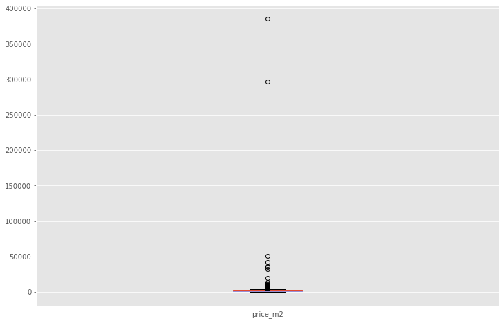

```python
data.boxplot(column=['price_m2'])
```

по графику видно, что данные сильно "загрязнены", т.к. являются источником информации, указанной самими продавцами и могут содержать разного рода ошибки. В частности самый дорогой объект имеет цену 385000 за квадратный метр в месяц, что скорее всего является общей ценой за все помещение.

Для данного категории предложений характерны следующие виды выбросов:

- ошибки в единицах измерений. По цене и/или площади, а также некорректный период, за который указана цена (год, месяц)
- дубли
- некорректная сегментация по типу объекта. Помещение расположено вблизи торгового центра, либо некоррекно указан адрес по принципу указания на близлежащий крупный объект
- некорректная сегментация по типу помещения (сдается часть, место в отделе и т.п.)
- некорректная сегментация по назначению и виду использования. Например, помещение классифицируют, как универсальное, тогда как в описании указано, что оно подходит только под услуги, либо является складским/производственным
- одно предложение содержит в себе несколько. Т.е. цена и площадь указаны номинально, а в описании расписаны возможные варианты для аренды разных помещений
- помещения сдаются в субаренду
- помещения с улучшениями (оборудованием, витринами и т.п.)

## Очистка данных

проверяем указанные в столбцах признаки (Тип объекта, Площадь, Цена) по описанию объекта в разрезе территорий по Районам города. Информацию о несоответсвии критериям выборки заносим в комментарий и исключаем неподходящие объекты по этому признаку.

```python
data = data[pd.isnull(data['comment'])]
data.shape
```

```
(1054, 10)
```

В итоге отброшено 14% от исходной выборки. Это достаточно большое количество, т.к. исходные данные изначально были сильно "загрязнены".

```python
#числовые статиситки
data.describe()[['price','area','price_m2']]
```

|  | price | area | price_m2 |
| --- | --- | --- | --- |
| count | 1054 | 1054 | 1054 |
| mean | 324022 | 256 | 1710 |
| std | 531207 | 485 | 1119 |
| min | 5000 | 4 | 190 |
| 25% | 50000 | 33 | 1000 |
| 50% | 125680 | 83 | 1440 |
| 75% | 357120 | 253 | 2000 |
| max | 4140000 | 4600 | 9483 |

```python
# построим диаграмму рассеяния по двум признакам: цена, площадь.
fig = px.scatter(data, x="price", y="area", width=400, height=400)
fig.update_layout(
        margin=dict(l=20, r=20, t=20, b=20),
        paper_bgcolor="LightSteelBlue",
    )
fig.show()
```

[interactive chart not shown]

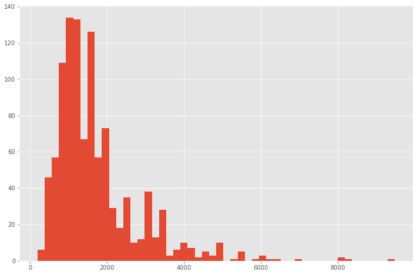

```python
# строим гистограмму распределения по цене за кв.м.
plt.hist(data['price_m2'], bins=50)
```

Цены предложений распределены неравномерно. 75% всех предложений попадают в диапазон до 2000 руб/м2/месяц. Тогда как самое дорогое в выборке с ценой 9483 руб/м2/мес.

Для дальнейшего исследования корректно использовать робастные статистики с целью соблюдения условия независимости влияния на результат смещений и выбросов.

## Исследуем цену по территориям

```python
# группируем данные по региону и создаем таблицу с основными статистиками по цене за квадратный метр
df_region = data.groupby('region', as_index=False)['price_m2'].agg(['median', 'min' , 'max', 'count']).sort_values('median', ascending=False)
df_region = df_region.to_csv('agr_region_type.csv')
```

### Геокодирование

```python
# добавляем в таблицу с расчетами данные о границах районов города
df_region = pd.read_csv('agr_region_type.csv')
full_data = df_region.merge(spb_geojson[['geometry', 'local_name']], left_on='region', right_on='local_name', how='left')
```

```python
# распределение диапазонов цен в Санкт-Петербурге по районам
full_data[['region', 'median', 'min', 'max']]
```

|  | region | median | min | max |
| --- | --- | --- | --- | --- |
| 0 | Центральный район | 2200 | 450 | 9483 |
| 1 | Петроградский район | 1925 | 500 | 4000 |
| 2 | Петродворцовый район | 1849 | 1275 | 2500 |
| 3 | Василеостровский район | 1800 | 700 | 7000 |
| 4 | Калининский район | 1776 | 400 | 5500 |
| 5 | Адмиралтейский район | 1700 | 900 | 2126 |
| 6 | Красносельский район | 1530 | 700 | 4000 |
| 7 | Кировский район | 1501 | 550 | 6500 |
| 8 | Курортный район | 1445 | 1445 | 1445 |
| 9 | Выборгский район | 1400 | 243 | 5882 |
| 10 | Московский район | 1380 | 400 | 8333 |
| 11 | Красногвардейский район | 1300 | 500 | 3235 |
| 12 | Невский район | 1300 | 500 | 5000 |
| 13 | Приморский район | 1200 | 300 | 6000 |
| 14 | Фрунзенский район | 1200 | 391 | 5000 |
| 15 | Пушкинский район | 882 | 190 | 2189 |
| 16 | Колпинский район | 765 | 400 | 3000 |
| 17 | Кронштадтский район | 577 | 500 | 900 |

```python
# строим карту распределение средних цен по районам
full_data = gpd.GeoDataFrame(full_data)
world_map = folium.Map(location=[59.9391, 30.31587])
folium.Choropleth(
    geo_data=full_data[['region', 'geometry']].to_json(),
    data=full_data[['region', 'median']],
    columns=['region', 'median'],
    key_on='feature.properties.region',
    fill_color='YlGnBu',
    line_weight=1,
    fill_opacity=0.7,
    line_opacity=0.2,
    legend_name='price_m2',
).add_to(world_map)

world_map
```

Make this Notebook Trusted to load map: File -> Trust Notebook

[interactive chart not shown]

### Срок экспозиции

расчитываем срок экспозиции для части предолжений: с даты публикации до даты снятия объявления с размещения.

```python
data_expos = data[pd.notnull(data['period_expos_day'])]
data_expos.shape
```

```
(398, 10)
```

в выборку попали 398 предложений

Расчитаем срок экспозиции по трем периодам:

```
* до 6 месяцев
* от 6 месяцев до 1 года
* от 1 года
```

```python
# функция для категоризации
def expos_distance(dis):
    if dis < pd.Timedelta('180 days'):
        return 'до 6 мес'
    elif dis < pd.Timedelta('365 days') and dis >= pd.Timedelta('180 days'):
        return 'от 6 мес до 1 года'
    elif dis >= pd.Timedelta('365 days'):
        return 'от 1 года'
```

```python
# категоризация
data['expos_category'] = data['period_expos_day'].apply(expos_distance)
```

```python
df_category_expos = data.groupby('expos_category')['price_m2'].agg(['median', 'min' , 'max', 'count']).sort_values('max')
df_category_expos
```

| expos_category | median | min | max | count |
| --- | --- | --- | --- | --- |
| до 6 мес | 1325 | 243 | 5000 | 104 |
| от 6 мес до 1 года | 1680 | 190 | 7000 | 191 |
| от 1 года | 1500 | 450 | 9483 | 103 |

```python
print('Средний срок экспозиции помещений в торговых центрах:', data['period_expos_day'].describe()['50%'].days, 'дня.')
```

```
Средний срок экспозиции помещений в торговых центрах: 227 дня.
```

Половина объектов сдаются в срок от 6 месяцев до 1 года. Предложения со сроком экспозиции до 6 месяцев в среднем дешевле на 12%.